# GLM - Generalized Linear Models

Sandeep Anand

April 22, 2017

# Generalized Linear Models

- We will use logistic regression as below when we would consider a Binomial outcome
- On the Logit scale you would like to see if the coefficient is close to 0 or not , on the exponential scale that should be 1

```r
#path = getwd()
#path_for_file = paste(path, "/RavensData/",sep="")
#dir.create(path_for_file)
#-- download.file() not working , pleae chek
#download.file("https://dl.dropbox.com/u/7710864/data/ravensData.rda",destfile="./RavensData/ravensData.rda",method="curl")
load("./RavensData/ravensData.rda")
head(ravensData)
```

```
##   ravenWinNum ravenWin ravenScore opponentScore
## 1           1        W         24             9
## 2           1        W         38            35
## 3           1        W         28            13
## 4           1        W         34            31
## 5           1        W         44            13
## 6           0        L         23            24
```

```r
logRegRavens<-glm(ravensData$ravenWin ~ ravensData$ravenScore, family = "binomial")
summary(logRegRavens)
```

```
##
## Call:
## glm(formula = ravensData$ravenWin ~ ravensData$ravenScore, family = "binomial")
##
## Deviance Residuals:
##     Min       1Q   Median       3Q      Max
## -1.7575  -1.0999   0.5305   0.8060   1.4947
##
## Coefficients:
##                       Estimate Std. Error z value Pr(>|z|)
## (Intercept)           -1.68001    1.55412  -1.081     0.28
## ravensData$ravenScore  0.10658    0.06674   1.597     0.11
##
## (Dispersion parameter for binomial family taken to be 1)
##
##     Null deviance: 24.435  on 19  degrees of freedom
## Residual deviance: 20.895  on 18  degrees of freedom
## AIC: 24.895
##
## Number of Fisher Scoring iterations: 5
```

## Fitten Curves

- Only a part of the S curve is shown below
- Component of the S curve where the data is present was restricted
- Took the X values , multiplied it with the coefficients , added the intercept to it and then got the ratio of exp(val)/(1+exp(val)) and that is the probability ie, on the Y asis
- equation block:
  $$P_r= \frac{\mathrm{e}^{p}}{(1+\mathrm{e}^{p})}$$

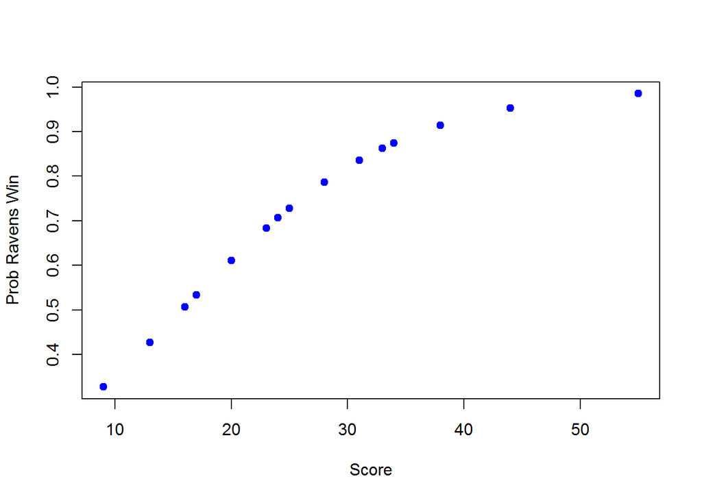

## Understanding the coefficients

### Sometool like Anova is very useful in porting a factor variable in and out of a model , when there a number of factor variables available

```r
exp(logRegRavens$coeff)
```

```
##           (Intercept) ravensData$ravenScore
##             0.1863724             1.1124694
```

```r
exp(confint(logRegRavens))
```

```
##                             2.5 %   97.5 %
## (Intercept)           0.005674966 3.106384
## ravensData$ravenScore 0.996229662 1.303304
```

```r
anova(logRegRavens, test="Chisq")
```

```
## Analysis of Deviance Table
##
## Model: binomial, link: logit
##
## Response: ravensData$ravenWin
##
## Terms added sequentially (first to last)
##
##
##                       Df Deviance Resid. Df Resid. Dev Pr(>Chi)
## NULL                                     19     24.435
## ravensData$ravenScore  1   3.5398        18     20.895  0.05991 .
## ---
## Signif. codes:  0 '***' 0.001 '**' 0.01 '*' 0.05 '.' 0.1 ' ' 1
```

## Interpreting Odds Ratios

- Not probabilities
- Odds ratio of 1 = no difference in odds
- Log odds ratio of 0 = no difference in odds
- Odds ratio < 0.5 or > 2 commonly a “moderate effect”
- Relative risk $\frac{\rm{Pr}(RW_i | RS_i = 10)}{\rm{Pr}(RW_i | RS_i = 0)}$ often easier to interpret, harder to estimate
- For small probabilities RR $\approx$ OR but they are not the same!

## Modelling Count Data - Poisson Distribution

- Poisson Distribution is useful model for counts and rates
- Modelling web traffic rates
- Contigency tables data
- Poisson Distribution becomes very much like a normal distributin as
  $$t\lambda$$
  , increases
- Mean and Variance of a Poisson Distribution are equal

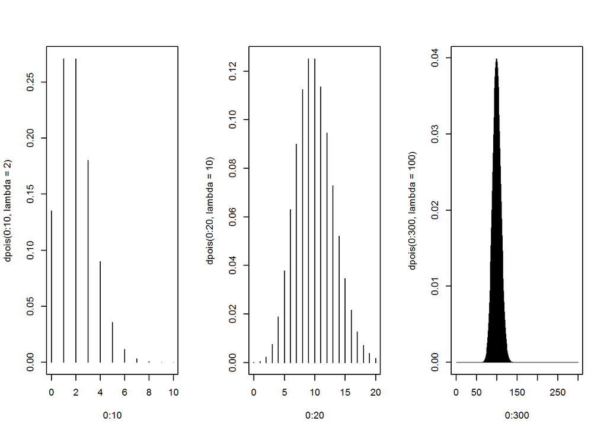

```r
par(mfrow=c(1,3))
plot(0:10, dpois(0:10, lambda = 2), type = "h", frame.plot = TRUE)
plot(0:20, dpois(0:20, lambda = 10), type = "h", frame.plot = TRUE)
plot(0:300, dpois(0:300, lambda = 100), type = "h", frame.plot = TRUE)
```